# Machine learning

Raphael Mourad, Maître de Conférences, Université Paul Sabatier

10/02/2021

## SETUP PROJECT FOLDER

Set up your project folder to your folder “atelier_INSERM”.

```r
knitr::opts_knit$set(root.dir = "/media/raphael/SSD2/atelier_INSERM")
knitr::opts_chunk$set(echo = TRUE)
```

## AIM OF THE SCRIPT

This script is used to train machine learning models for binary classification of positive and negative peak sequences.

## LOAD LIBRARIES

Load R librairies. Remove suppressPackageStartupMessages() for debugging!

```r
suppressPackageStartupMessages(library(GenomicRanges))
suppressPackageStartupMessages(library(gkmSVM))
suppressPackageStartupMessages(library(Biostrings))
suppressPackageStartupMessages(library(JASPAR2020))
suppressPackageStartupMessages(library(TFBSTools))
suppressPackageStartupMessages(library(motifmatchr))
suppressPackageStartupMessages(library(kebabs))
suppressPackageStartupMessages(library(pROC))
suppressPackageStartupMessages(library(glmnet))
suppressPackageStartupMessages(library(doParallel))
suppressPackageStartupMessages(library(ranger))
suppressPackageStartupMessages(library(e1071))
```

## LOAD FUNCTIONS

```r
suppressPackageStartupMessages(source("scriptR/functions.R"))
```

## SOME PARAMETERS

Define parameters for the analysis:  
- peakSize is the resized peak size. For machine/deep learning, it is easier to work with peaks have the same size.  
- kpeaks is the number of best peaks used. Note that all peaks can also be used.  
- expe is the ChIP-seq experiment. For instance, CTCF for CTCF ChIP-seq or POL2 for RNA Polymerase 2 ChIP-seq experiment.

```r
peakSize=201
kpeaks=4000
expe="DNase"
DNAletters=c("A","C","G","T")
```

## INPUT FILE NAMES

Set file names, which includes:  
- positive peaks from ChIP-seq and negative peaks from the control generator function genNullSeqs().  
- bed (genomic ranges) and fasta files (corresponding DNA sequences).

```r
fileBedPos=paste0("data/bed/",expe,"_GM12878_hg19_",kpeaks,"_pos.bed")
fileBedNeg=paste0("data/bed/",expe,"_GM12878_hg19_",kpeaks,"_neg.bed")
fileFastaPos=paste0("data/fasta/",expe,"_GM12878_hg19_",kpeaks,"_pos.fa")
fileFastaNeg=paste0("data/fasta/",expe,"_GM12878_hg19_",kpeaks,"_neg.fa")
```

## LOAD PROCESSED DATA

Load ChIP-seq and control fasta sequences:

```r
peakPos.seq=readDNAStringSet(fileFastaPos)
peakNeg.seq=readDNAStringSet(fileFastaNeg)
print(peakPos.seq)
```

```
## DNAStringSet object of length 4000:
##        width seq                                            names
##    [1]   201 AATGACCCACCAATCACATGCC...TGTAACACGAGAAAGCACATA chr1_1
##    [2]   201 TCATCACTAGACATCGTACTAC...GTAAATCTAACTTTCTTCCCA chr1_2
##    [3]   201 CCCTATTAGTGGGTGAACAATC...TGAGGCCCCGCTTTCACGGTC chr1_3
##    [4]   201 TTTGCTAGGCAGAATAGTAATG...ATAATTATGCCTCACAGGGAT chr5_4
##    [5]   201 CGGGTCTTCCAGGAGTCGGGTT...CCGCGCAGTCCGCCCGGAGGA chr11_5
##    ...   ... ...
## [3996]   201 AACAGGAAGTCACAGCACTCGA...CATGCATTACTCAGTGTGATA chr6_3996
## [3997]   201 GCGCCCCGCAGGCCCGCCCACT...CGCGAGGCCGGCCTGAGGGAG chr7_3997
## [3998]   201 GCCATTGCCGTCCACCCCGGAA...GTGGGCTAGTCTTCGGACGGC chr7_3998
## [3999]   201 GGACGCACAGGAAGCGAGGGCA...CATTTGAAATGTCTCTATCTG chr7_3999
## [4000]   201 CCTTGCGATTCCCTTCGCCACT...CGCTGATTGGCTGCCGAGACC chr7_4000
```

Bind positive and negative sequences, and make label:

```r
peakAll.seq=c(peakPos.seq,peakNeg.seq)
label=c(rep(1,length(peakPos.seq)),rep(0,length(peakNeg.seq)))
```

Shuffle sequence indices:

```r
idxS=sample(1:length(peakAll.seq))
peakAllS.seq=peakAll.seq[idxS]
labelS=label[idxS]
print(labelS[1:5])
```

```
## [1] 1 0 1 1 0
```

Split train and test indices:

```r
percTrain=0.7
idxTrain=1:(ceiling(length(labelS)*percTrain))
idxTest=(length(idxTrain)+1):length(labelS)
labelTrain=labelS[idxTrain]
labelTest=labelS[idxTest]
```

## BUILD FEATURES FOR MACHINE LEARNING

Parallel computing (for glmnet)

```r
registerDoParallel(4)
```

K-mer counts as features. Here we used gapped k-mers which allow some flexibility. For instance: ATTNNNTGC is a gapped k-mer of parameter k=3 and m=3.

```r
specK=gappyPairKernel(k=3, m=3, normalized=F) # normalization accounts for different sequence length
kmerAllS=getExRep(peakAllS.seq,kernel=specK,sparse=T)
kmerAllS=as(kmerAllS,"Matrix")
kmerTrain=kmerAllS[idxTrain,]
kmerTest=kmerAllS[idxTest,]
print(kmerTrain[1:5,1:5])
```

```
## 5 x 5 sparse Matrix of class "dgTMatrix"
##            AAAAAA AAA.AAA AAA..AAA AAA...AAA AAAAAC
## chr1_1934       .       .        .         .      .
## chr22_1207      .       .        .         .      .
## chr3_542        .       .        1         2      .
## chr19_430       .       1        .         .      .
## chr2_1202       .       .        .         .      1
```

Position Weigth Matrix (PWM) motif counts as features.  
Load DNA binding protein motif PWMs from JASPAR database:

```r
opts <- list(species=9606, all_versions=TRUE)
PFMatrixList <- getMatrixSet(JASPAR2020, opts)
proteinNames=name(PFMatrixList)
motifID=names(PFMatrixList)
print(PFMatrixList[[1]])
```

```
## An object of class PFMatrix
## ID: MA0002.1
## Name: RUNX1
## Matrix Class: Runt domain factors
## strand: +
## Tags:
## $comment
## [1] "Matrix changed since last release: removal of primers and sites overlapping primers"
##
## $family
## [1] "Runt-related factors"
##
## $medline
## [1] "8413232"
##
## $tax_group
## [1] "vertebrates"
##
## $tfbs_shape_id
## [1] "1"
##
## $type
## [1] "SELEX"
##
## $collection
## [1] "CORE"
##
## $species
##           9606
## "Homo sapiens"
##
## $acc
## [1] "Q01196"
##
## Background:
##    A    C    G    T
## 0.25 0.25 0.25 0.25
## Matrix:
##   [,1] [,2] [,3] [,4] [,5] [,6] [,7] [,8] [,9] [,10] [,11]
## A   10   12    4    1    2    2    0    0    0     8    13
## C    2    2    7    1    0    8    0    0    1     2     2
## G    3    1    1    0   23    0   26   26    0     0     4
## T   11   11   14   24    1   16    0    0   25    16     7
```

DNA motif counts:

```r
motif_ix=matchMotifs(PFMatrixList,peakAllS.seq,out="scores",p.cutoff=1e-4)
mcAllS=motifCounts(motif_ix)
mcTrain=mcAllS[idxTrain,]
mcTest=mcAllS[idxTest,]
print(mcTrain[1:5,1:10])
```

```
## 5 x 10 sparse Matrix of class "dgCMatrix"
```

```
##    [[ suppressing 10 column names 'MA0002.1', 'MA0003.1', 'MA0017.1' ... ]]
```

```
##
## [1,] . . . . . . . . . .
## [2,] . . . . . . . . . .
## [3,] . . . . . . . . . .
## [4,] . . . . . . . . . .
## [5,] . . . . . . . . . .
```

## USING KMERS

Lasso logistic regression.  
NB: glmnet is optimized for sparse X input matrix.

```r
cvlasso_kmer=cv.glmnet(x=kmerTrain,y=labelTrain,family="binomial",parallel=TRUE)
print(cvlasso_kmer)
```

```
##
## Call:  cv.glmnet(x = kmerTrain, y = labelTrain, parallel = TRUE, family = "binomial")
##
## Measure: Binomial Deviance
##
##       Lambda Index Measure      SE Nonzero
## min 0.005088    71  0.5852 0.01616    1152
## 1se 0.007734    62  0.5983 0.01393     840
```

```r
predLasso_kmer=predict(cvlasso_kmer,newx=kmerTest,type="response")[,1]
print(predLasso_kmer[1:5])
```

```
##  chr12_977 chr11_1144  chr3_2477 chr22_3011  chr8_2627
##  0.9656083  0.3382332  0.8395500  0.5626839  0.0937986
```

```r
rocLasso_kmer=pROC::roc(as.factor(labelTest),predLasso_kmer,ci=T)
```

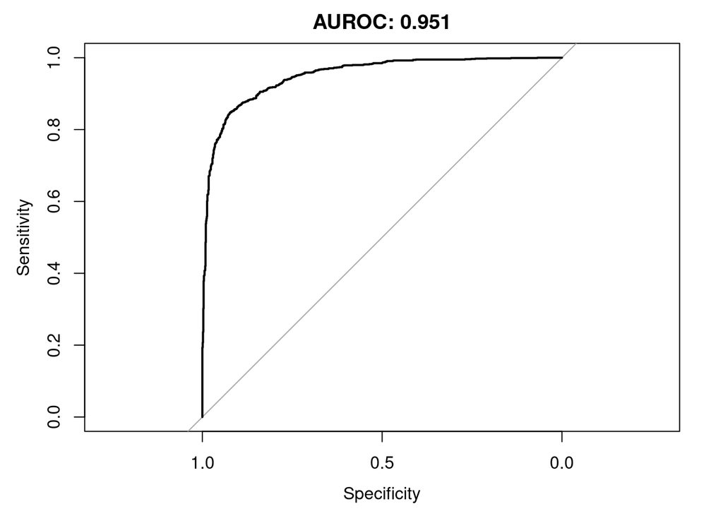

```r
plot(rocLasso_kmer,main=paste0("AUROC: ", round(pROC::auc(rocLasso_kmer),3)))
```

## USING DNA MOTIFS

Lasso logistic regression:

```r
cvlasso_motif=cv.glmnet(x=mcTrain,y=labelTrain,family="binomial",parallel=TRUE)
predLasso_motif=predict(cvlasso_motif,newx=mcTest,type="response")[,1]
rocLasso_motif=pROC::roc(as.factor(labelTest),predLasso_motif,ci=T)
```

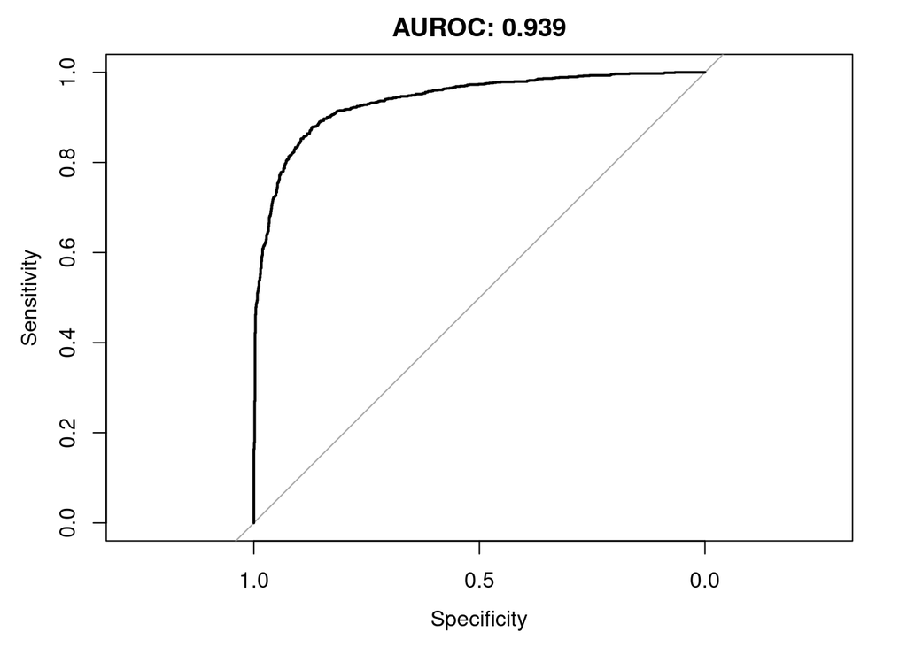

```r
plot(rocLasso_motif,main=paste0("AUROC: ", round(pROC::auc(rocLasso_motif),3)))
```

Random forests:

```r
dataRF_motif=data.frame(label=labelTrain,as(mcTrain,"matrix"))
RF_motif=ranger(label ~ .,data=dataRF_motif,importance="permutation")
predRF_motif=predict(RF_motif,data=data.frame(as(mcTest,"matrix")))$predictions
rocRF_motif=pROC::roc(as.factor(labelTest),predRF_motif,ci=T)
```

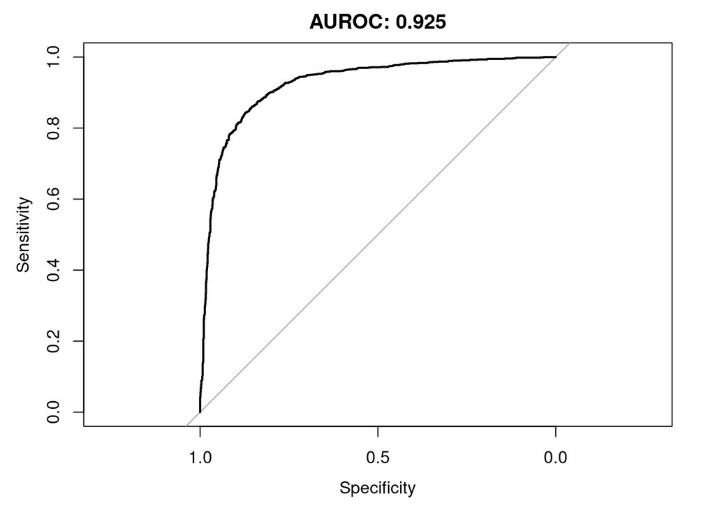

```r
plot(rocRF_motif,main=paste0("AUROC: ", round(pROC::auc(rocRF_motif),3)))
```

Extract variable importances from random forests. Allows to evaluate the predictive power of each feature.

```r
dataImportanceMotif=data.frame(motifID,proteinNames,nameID=paste0(motifID,"_",proteinNames),importance=importance(RF_motif))
dataImportanceMotif=dataImportanceMotif[order(importance(RF_motif),decreasing=T)[1:20],]
dataImportanceMotif=dataImportanceMotif[order(dataImportanceMotif[,4]),]
```

Plot variable importances.

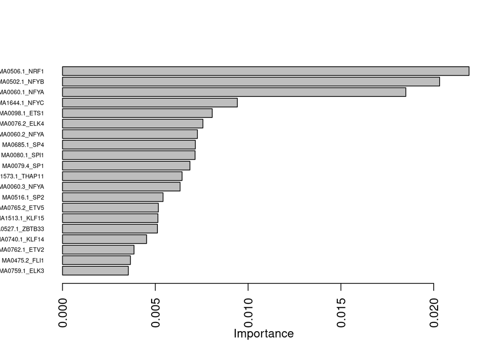

```r
#knitr::opts_chunk$set(fig.width=40, fig.height=30)
#par(mar=rep(10,4))
barplot(dataImportanceMotif[,4],names.arg=dataImportanceMotif[,3],cex.names=0.5,horiz=T,las=2,xlab="Importance")
```

```r
#knitr::opts_chunk$set(fig.width=7, fig.height=7)
```

Support vector machine (a bit slow):

```r
#SVM_motif=svm(label ~ ., data=dataRF_motif, kernel="linear",scale=F)
#predSVM_motif=predict(SVM_motif,newdata=data.frame(as(mcTest,"matrix")))
#rocSVM_motif=pROC::roc(as.factor(labelTest),predSVM_motif,ci=T)
#plot(rocSVM_motif,main=paste0("AUROC: ", round(pROC::auc(rocSVM_motif),3)))
```